# 20221216-BCoAT_genome_compare

Jinlong Ru 12/16/22

- Visualize using `gggenomes`
  - BCoAT in viral contig BAF3_V__NODE_17
  - BCoAT in viral contig BAM6_V__NODE_3

**Updated: 2023-01-30 18:47:42 CET.**

# Visualize using `gggenomes`

```r
library(gggenomes)
```

```
Transforming sublinks with "aa2nuc". Disable with `.transform = "none"`

Flipping: 2,3,4

Warning: Removed 95 rows containing missing values (`geom_feat_text()`).
```

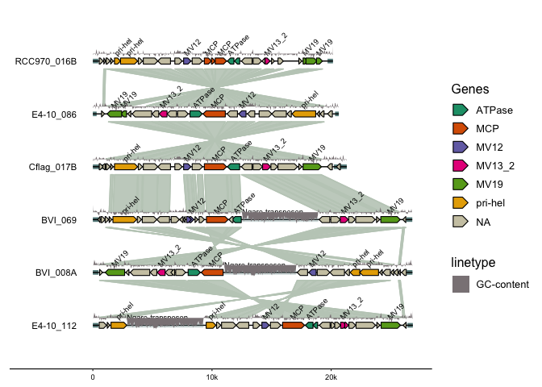

```r
gggenomes(emale_genes, emale_seqs, emale_tirs, emale_ava) %>%
  add_feats(ngaros=emale_ngaros, gc=emale_gc) %>%
  add_sublinks(emale_prot_ava) %>%
  flip_by_links() +
  geom_feat(position="identity", size=6) +
  geom_seq() +
  geom_link(data=links(2)) +
  geom_bin_label() +
  geom_gene(aes(fill=name)) +
  geom_gene_tag(aes(label=name), nudge_y=0.1, check_overlap = TRUE) +
  geom_feat(data=feats(ngaros), alpha=.3, size=10, position="identity") +
  geom_feat_note(aes(label="Ngaro-transposon"), feats(ngaros),
      nudge_y=.1, vjust=0) +
  geom_ribbon(aes(x=(x+xend)/2, ymax=y+.24, ymin=y+.38-(.4*score),
      group=seq_id, linetype="GC-content"), feats(gc),
      fill="lavenderblush4", position=position_nudge(y=-.1)) +
  scale_fill_brewer("Genes", palette="Dark2", na.value="cornsilk3")
```

```r
ggsave(path_target("emales.png"), width=8, height=4)
```

**Updated: 2022-12-16**

Two Viral BCoAT protein sequences were searched against NCBI NR database. The top protein hit in bacterial reference genome was selected as the best target, and the bacterial genome was compared with viral genome as show below.

### BCoAT in viral contig BAF3_V__NODE_17

Bacterial `Pseudoflavonifractor sp. AF19-9AC` contains BCoAT that most similar to viral contig `BAF3_V__NODE_17` encoded BCoAT gene, so we compared BCoAT region of their genomes, as show below. BCoAT gene was colored in red, and was connected with lines according to identity by BLASTn alignment. The high identity in BCoAT gene and no identity in surrounding genes indicate the viral-encoded BCoAT gene was from bacterial genome. Upper part is bacterial genome, and lower part is viral contig.

[figure not shown]

Figure 1. BCoAT in Pseudoflavonifractor sp. AF19-9AC and BAF3_V__NODE_17

### BCoAT in viral contig BAM6_V__NODE_3

Bacterial `PLawsonibacter sp. OA9` contains BCoAT that most similar to viral contig `BAM6_V__NODE_3` encoded BCoAT gene, so we compared BCoAT region of their genomes, as show below. BCoAT gene was colored in red, and was connected with lines according to identity by BLASTn alignment. The high identity in BCoAT gene and no identity in surrounding genes indicate the viral-encoded BCoAT gene was from bacterial genome. Upper part is bacterial genome, and lower part is viral contig.

[figure not shown]

Figure 2. BCoAT in PLawsonibacter sp. OA9 and BAM6_V__NODE_3